# Plant Seedlings Image classification using CNNs in Keras

# 0. Project Description

## 0.1 Dataset

### Data Description

You are provided with a dataset of images of plant seedlings at various stages of grown. Each image has a filename that is its unique id. The dataset comprises 12 plant species. **The goal of the project is to create a classifier capable of determining a plant's species from a photo.**

### Dataset

The dataset can be download from Olympus.

The data file names are:

- images.npy
- Label.csv

The original files are from Kaggle. Due to the large volume of data, the images were converted to images.npy file and the labels are also put into the Labels.csv. So that you can work on the data/project seamlessly without worrying about the high data volume.

The following code was used to convert the large dataset of images to numpy array:

```
    # Import necessary libraries.
    import math
    import numpy as np
    import pandas as pd
    from glob import glob
    data_path = '/content/drive/My Drive/Colab Notebooks/data/plant_seedlings/train.zip'
    !mkdir dataset

    # Extract the files from dataset to temp_train and temp_test folders (as the dataset is a zip file.)
    from zipfile import ZipFile
    with ZipFile(data_path, 'r') as zip:
      zip.extractall('./dataset')
    path = "/content/dataset/*/*.*"  # The path to all images in training set. (* means include all folders and files.)
    files = glob(path)

    trainImg = [] # Initialize empty list to store the image data as numbers.
    trainLabel = [] # Initialize empty list to store the labels of images
    j = 1
    num = len(files)

    # Obtain images and resizing, obtain labels
    for img in files:
      '''
      Append the image data to trainImg list.
      Append the labels to trainLabel list.
      '''
      print(str(j) + "/" + str(num), end="\r")
      trainImg.append(cv2.resize(cv2.imread(img), (128, 128))) # Get image (with resizing to 128x128)
      trainLabel.append(img.split('/')[-
    2]) # Get image label (folder name contains the class to which the image belong)
      j += 1

    trainImg = np.asarray(trainImg) # Train images set
    trainLabel = pd.DataFrame(trainLabel, columns=["Label"]) # Train labels set
    print(trainImg.shape)
    print(trainLabel.shape)
    trainLabel.to_csv('Labels.csv', index=False)
    np.save('plantimages', trainImg)
```

## 0.2 Context, Objective, and Learning Outcomes

### Context

Can you differentiate a weed from a crop seedling?

The ability to do so effectively can mean better crop yields and better stewardship of the environment.

The Aarhus University Signal Processing group, in collaboration with University of Southern Denmark, has recently released a dataset containing images of unique plants belonging to 12 species at several growth stages

### Objective

To implement the techniques learnt as a part of the course.

### Learning Outcomes

- Pre-processing of image data.
- Visualization of images.
- Building CNN.
- Evaluate the Model.
- The motive of the project is to make the learners capable to handle images/image classification problems, during this process you should also be capable to handle real image files, not just limited to a numpy array of image pixels.

## 0.3 Guide to Solving the Project Seamlessly

Here are the points which will help you to solve the problem efficiently:

- Read the problem statement carefully from start to end (including the note at the end). The highlighted part in the attached problem statement should not be missed.
- Download the dataset from the Olympus platform.
- Upload the "images.npy" and “Labels.csv” file to google drive.
- Then you can use the dataset path in the Google Colab notebook to do further steps related to project problem statement.
- You can set runtime type to “GPU” in Google Colab, so that the code will run faster as you will be using CNN to fit your model.

## 0.4 Steps and Tasks

1. Import the libraries, load dataset, print shape of data, visualize the images in dataset. (5 Marks)
2. Data Pre-processing: (15 Marks)
   1. Normalization.
   2. Gaussian Blurring.
   3. Visualize data after pre-processing.
3. Make data compatible: (10 Marks)
   1. Convert labels to one-hot-vectors.
   2. Print the label for y_train[0].
   3. Split the dataset into training, testing, and validation set.
      - (Hint: First split images and labels into training and testing set with test_size = 0.3. Then further split test data into test and validation set with test_size = 0.5)
   4. Check the shape of data, Reshape data into shapes compatible with Keras models if it’s not already. If it’s already in the compatible shape, then comment in the notebook that it’s already in compatible shape.
4. Building CNN: (15 Marks)
   1. Define layers.
   2. Set optimizer and loss function. (Use Adam optimizer and categorical crossentropy.)
5. Fit and evaluate model and print confusion matrix. (10 Marks)
6. Visualize predictions for x_test[2], x_test[3], x_test[33], x_test[36], x_test[59]. (5 Marks)

## 0.5 Note

- Download the train images from the Olympus Platform.
- Do not download the dataset from Kaggle, as:
  - The dataset is big.
  - The dataset has 2 files for train and test images, but the labels are only for the train file. Test file has no labels associated with it. So, when you want to know the accuracy of model on test images, there’s no way to measure it. That’s why the data provided to you on Olympus has only train images and their labels. For our purpose we use this for our training and testing and validation purpose.

Happy Learning!

# 1. Import, Load, and Verify (5 Marks)

1. Import Libraries
2. Load Dataset
3. Print Shape of Data
4. Visualize the Images in Dataset

## 1.1 Import Libraries

```python
import pandas as pd
import numpy as np
import matplotlib.pyplot as plt
%matplotlib inline

import cv2

from sklearn.preprocessing import OneHotEncoder
from sklearn.model_selection import train_test_split
from sklearn.metrics import confusion_matrix

from tensorflow.keras.models import Sequential
from tensorflow.keras.layers import Conv2D, Flatten, Dense
from tensorflow.keras.callbacks import EarlyStopping
```

```python
from google.colab import drive
drive.mount('/content/gdrive')
```

## 1.2 Load Dataset

```python
labels = pd.read_csv('/content/gdrive/My Drive/aiml/courses/intro-computer-vision-210501SA/project-computer-vision/Labels.csv')
```

```python
images = np.load('/content/gdrive/My Drive/aiml/courses/intro-computer-vision-210501SA/project-computer-vision/images.npy')
```

## 1.3 Shape of Data

```python
labels.shape
```

```
(4750, 1)
```

```python
images.shape
```

```
(4750, 128, 128, 3)
```

## 1.4 Visualize Images

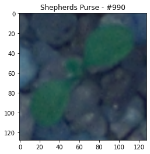

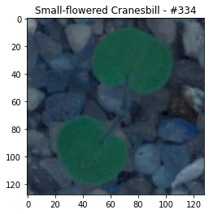

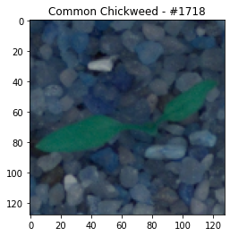

```python
rand_imgs = np.random.randint(len(images), size=3)
for img in rand_imgs:
  plt.imshow(images[img], cmap='gray')
  plt.title(labels.Label[img] + " - #" + str(img))
  plt.show()
```

# 2. Data Pre-processing (15 Marks)

1. Normalization.
2. Gaussian Blurring.
3. Visualize data after pre-processing.

## 2.1 Normalization

```python
images = images.astype('float32')
images /= 255
```

## 2.2 Gaussian Blurring

```python
images_blurred = np.copy(images) # create copy of images numpy array to store blurred images

for i in np.arange(len(images)): # loop through images
  images_blurred[i] = cv2.GaussianBlur(images[i], (5, 5), 0) # blur and store into numpy array copy
```

```python
print('images: ')
print(images.shape, images.dtype)
print('images_blurred: ')
print(images_blurred.shape, images_blurred.dtype)
```

```
images:
(4750, 128, 128, 3) float32
images_blurred:
(4750, 128, 128, 3) float32
```

## 2.3 Visualize

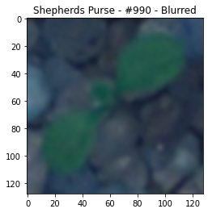

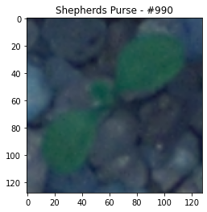

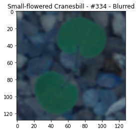

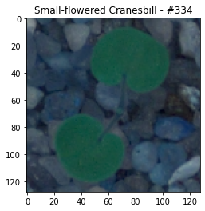

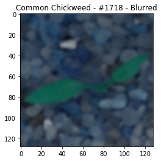

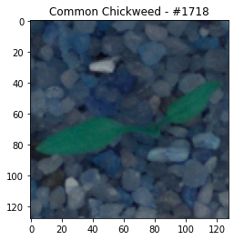

```python
for img in rand_imgs:
  plt.imshow(images_blurred[img], cmap='gray')
  plt.title(labels.Label[img] + " - #" + str(img) + " - Blurred")
  plt.show()
  plt.imshow(images[img], cmap='gray')
  plt.title(labels.Label[img] + " - #" + str(img))
  plt.show()
```

# 3. Make Data Compatible (10 Marks)

1. Convert labels to one-hot-vectors.
2. Print the label for y_train[0].
3. Split the dataset into training, testing, and validation set.
   - (Hint: First split images and labels into training and testing set with test_size = 0.3. Then further split test data into test and validation set with test_size = 0.5)
4. Check the shape of data, Reshape data into shapes compatible with Keras models if it’s not already. If it’s already in the compatible shape, then comment in the notebook that it’s already in compatible shape.

## 3.1 Convert Labels to One-Hot Vectors

```python
unique_labels_df = pd.DataFrame(labels.Label.unique(), columns=['unique_labels'])
unique_labels_df
```

|  | unique_labels |
| --- | --- |
| 0 | Small-flowered Cranesbill |
| 1 | Fat Hen |
| 2 | Shepherds Purse |
| 3 | Common wheat |
| 4 | Common Chickweed |
| 5 | Charlock |
| 6 | Cleavers |
| 7 | Scentless Mayweed |
| 8 | Sugar beet |
| 9 | Maize |
| 10 | Black-grass |
| 11 | Loose Silky-bent |

```python
# one-hot encoded labels
labels_ohe = OneHotEncoder().fit_transform(labels).toarray()
```

```python
labels_ohe
```

```
array([[0., 0., 0., ..., 0., 1., 0.],
       [0., 0., 0., ..., 0., 1., 0.],
       [0., 0., 0., ..., 0., 1., 0.],
       ...,
       [0., 0., 0., ..., 0., 0., 0.],
       [0., 0., 0., ..., 0., 0., 0.],
       [0., 0., 0., ..., 0., 0., 0.]])
```

```python
# length of first record matches the total number of unique labels
len(labels_ohe[0])
```

```
12
```

## 3.2 Print the Label for y_train[0]

```python
# Note: dataset has not yet been split into training, testing, and validation - this will happen in the next step.
# As such, there is no y_train[0] at this step, but there is a label_ohe[0], which is what I will be printing.

labels_ohe[0]
```

```
array([0., 0., 0., 0., 0., 0., 0., 0., 0., 0., 1., 0.])
```

## 3.3 Split the Dataset into Training, Testing, and Validation Set.

```python
# Assign images and labels into corresponding X and y variables
X = images_blurred
y = labels_ohe
```

```python
# Split X and y into training and testing set with a 70/30 split
X_train, X_test, y_train, y_test = train_test_split(X, y, test_size=0.30, random_state=88)
```

```python
# Split X_test and y_test intro validation and testing set with a 50/50 split
X_valid, X_test, y_valid, y_test = train_test_split(X_test, y_test, test_size=0.50, random_state=88)
```

## 3.4 Check the Shape of Data

```python
shape_data = [[X_train.shape, y_train.shape],[X_valid.shape, y_valid.shape],[X_test.shape, y_test.shape]]
shape_df = pd.DataFrame(shape_data, columns=['X_', 'y_'], index=['train.shape', 'valid.shape', 'test.shape'])
shape_df
```

|  | X_ | y_ |
| --- | --- | --- |
| train.shape | (3325, 128, 128, 3) | (3325, 12) |
| valid.shape | (712, 128, 128, 3) | (712, 12) |
| test.shape | (713, 128, 128, 3) | (713, 12) |

Data does **not** need to be reshaped as the Sequential model in tensorflow.keras expects data to be in the format (Data Length, Height, Width, Color Channels) which it is already in.

# 4. Building CNN (15 Marks)

1. Define layers.
2. Set optimizer and loss function. (Use Adam optimizer and categorical crossentropy.)

## 4.1 Define Layers

```python
model = Sequential()
model.add(Conv2D(filters=32, kernel_size=3, activation="relu", input_shape=(128, 128, 3)))
model.add(Conv2D(filters=32, kernel_size=3, activation="relu"))
model.add(Flatten())
model.add(Dense(128, activation="relu"))
model.add(Dense(12, activation="softmax"))
```

## 4.2. Set optimizer and loss function.

```python
model.compile(loss="categorical_crossentropy", metrics=["accuracy"], optimizer="adam")
```

# 5. Fit and evaluate model and print confusion matrix. (10 Marks)

## 5.1 Fit

```python
earlystop = EarlyStopping(monitor='val_accuracy', min_delta=0.0001, patience=4)
```

```python
model.fit(x=X_train, y=y_train, batch_size=32, epochs=12, validation_data=(X_valid,y_valid), callbacks=[earlystop])
```

```
<tensorflow.python.keras.callbacks.History at 0x7f30b48fc410>
```

### 5.2 Evaluate

```python
model.evaluate(X_test, y_test)
```

```
[1.9069167375564575, 0.6283310055732727]
```

## 5.3 Confusion Matrix

```python
y_true=np.argmax(y_test, axis=1)
y_true
```

```
array([ 7, 11, 11, 11,  7,  1,  5,  4, 11,  3,  0,  9,  3, 10, 10,  1,  8,
        2,  6,  8,  6, 10,  6,  0,  9,  6,  4, 11,  8, 10, 10,  7,  4,  8,
        9,  9,  3,  3,  3,  2,  2, 10,  5,  8,  8,  7,  4, 10,  6, 10,  6,
        8, 11,  8,  5,  8,  9, 11,  8,  3, 11,  2,  9,  6, 10,  5,  6, 10,
        3,  5,  3,  4,  3, 10,  7,  8,  6, 10,  1,  5,  0,  8,  9,  1,  0,
        4,  5,  4,  0,  5,  4,  9,  1,  3,  2,  1,  3, 10,  7,  3,  7,  0,
        3,  8, 11, 10, 10, 11, 11,  9,  3, 11,  2, 10,  9,  4,  4,  1, 10,
        3,  1,  2,  4, 11,  4,  6,  8,  4,  6,  7,  2,  1,  1,  6,  6,  3,
       11,  0,  5,  7,  3,  5,  3,  5,  4,  3,  0,  9,  3,  9,  5, 11,  6,
        4,  6,  1,  4, 10,  1, 10,  5,  3,  6,  5,  4,  3, 10,  9,  6,  9,
        3,  0,  3,  6,  3,  9,  6,  0,  3,  6,  6,  4,  8, 11,  0,  2, 11,
        6,  5, 11,  3,  6,  3,  5,  0,  7,  6,  7,  3, 11,  5,  1,  2,  5,
        0,  1,  8,  6,  3,  2,  7, 10,  5,  3,  6,  3,  3,  3,  8,  4,  6,
        6,  2,  6,  3,  1,  5,  6,  3,  5,  4,  8,  9, 10,  8,  9,  5,  9,
        8, 10,  5,  6,  0,  3, 11,  7,  2,  8,  1,  2,  1, 10,  2,  0,  6,
```

[output cut: 27 more lines]

```python
y_pred = np.argmax(model.predict(X_test), axis=1)
y_pred
```

```
array([ 7, 11, 10,  3,  7,  1,  5,  0,  7,  3,  5,  9,  3,  7, 10,  1,  8,
        8,  6,  8, 11, 10,  0,  6,  8,  6,  4, 11,  8,  7, 10,  7,  6, 11,
        5,  7,  3,  3,  3,  2,  2, 10, 11, 11,  8,  7,  2, 10,  6, 10,  6,
        8, 11,  8,  8,  7, 10, 11,  8,  3,  3,  2,  5, 11, 10,  5,  6, 10,
        3,  5,  3, 11,  3, 10,  7,  8,  6, 10,  1,  5, 11, 11, 10,  1,  6,
        0,  5, 11,  6,  5,  0,  9,  1,  3,  1,  1,  3, 10,  7,  3,  7,  5,
        3,  8, 11,  3, 10, 11, 10,  9,  3, 11,  2, 10,  9,  2,  4,  1, 10,
        3,  1,  2,  6, 11,  6,  3, 11,  0, 11, 11,  2, 11,  1,  5,  6,  3,
       11,  6,  3,  7,  3,  3,  3,  5,  6, 10,  6,  9,  3,  9,  4,  5,  0,
        4, 11,  1,  3, 10,  1, 10,  5,  3,  6,  5,  0,  3, 10,  9,  6,  9,
        3,  0,  3, 11,  3,  5,  6,  6,  3,  4,  0,  4, 11, 11,  6,  2, 11,
        6, 11, 11,  9,  0,  3,  8,  0,  7,  8,  7,  3, 11, 11,  1,  2,  5,
        0,  1, 11,  6,  3,  2,  7, 10,  8,  3,  6,  3,  3,  3,  8,  6,  6,
        4,  1,  6,  3,  1,  5,  0,  3,  5,  0,  8,  8, 10,  8,  9,  5,  9,
        8,  3, 11,  5,  6,  3, 11,  7,  2,  8, 10, 11,  1, 10,  2,  0,  0,
```

[output cut: 27 more lines]

```python
conf_mat = confusion_matrix(y_true, y_pred)
conf_mat
```

```
array([[ 9,  0,  0,  0,  4,  4, 18,  1,  0,  0,  0,  3],
       [ 0, 59,  2,  0,  0,  1,  0,  0,  0,  1,  2,  2],
       [ 0, 11, 30,  0,  0,  1,  0,  0,  3,  2,  3,  2],
       [ 0,  1,  0, 73,  0,  1,  0,  2,  3,  4,  1,  0],
       [ 8,  0,  3,  2, 11,  4, 13,  0,  1,  0,  0,  3],
       [ 0,  2,  2,  5,  2, 43,  0,  0,  4,  2,  2, 11],
       [12,  0,  1,  1, 11, 10, 51,  1,  2,  0,  1,  6],
       [ 0,  0,  0,  4,  0,  1,  0, 21,  2,  2,  0,  1],
       [ 0,  2,  2,  2,  1,  2,  0,  1, 44,  2,  0, 18],
       [ 0,  2,  0,  2,  0,  3,  0,  3,  3, 19,  6,  0],
       [ 0,  0,  0,  3,  0,  0,  0,  2,  0,  0, 49,  2],
       [ 0,  0,  0,  3,  0,  6,  0,  1,  2,  1,  5, 39]])
```

# 6. Visualize predictions (5 Marks)

1. x_test[2]
2. x_test[3]
3. x_test[33]
4. x_test[36]
5. x_test[59].

## 6.1 Labels Insight

```python
labels.iloc[0,0]
```

```
'Small-flowered Cranesbill'
```

Insight: The seedling name of the 1st record in the labels dataframe is 'Small-flowered Cranesbill'.

```python
labels_ohe[0]
```

```
array([0., 0., 0., 0., 0., 0., 0., 0., 0., 0., 1., 0.])
```

Insight: We have an int 1 at index 10 of the first record in the one-hot encoded labels.

```python
np.sort(labels.Label.unique())
```

```
array(['Black-grass', 'Charlock', 'Cleavers', 'Common Chickweed',
       'Common wheat', 'Fat Hen', 'Loose Silky-bent', 'Maize',
       'Scentless Mayweed', 'Shepherds Purse',
       'Small-flowered Cranesbill', 'Sugar beet'], dtype=object)
```

Insight: When we take the unique values of the Label column in the labels dataframe and sort them, i.e. alphabetize the unique labels, we see that 'Small-flowered Cranesbill' ends up at index 10.

### Overall Insights:

- One-hot encoding appears to sort the values by name - alphabetize
- It places an int 1 at the corresponding index
- In the above example, when the labels are sorted by name, 'Small-flowered Cranesbill' ends up at index 10
- Index 10 corresponds with the one-hot encoded value of 1 at index 10 for `labels_ohe[0]`

## 6.2 Visualize Predictions

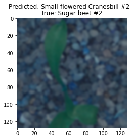

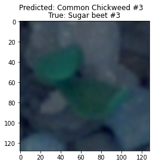

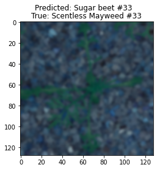

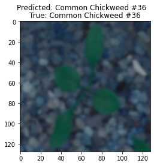

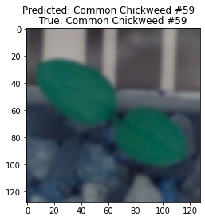

```python
vis_pred_imgs = np.array([2, 3, 33, 36, 59]) # create array of requested images to visualize

for img in vis_pred_imgs:
  label_index_true = y_true[img] # return the label index of y_true
  label_name_true = np.sort(labels.Label.unique())[label_index_true] # sort the unique labels by name, then return the label name where the index matches the above value
  label_index_pred = y_pred[img] # y_pred index
  label_name_pred = np.sort(labels.Label.unique())[label_index_pred] # y_pred label
  plt.imshow(X_test[img], cmap='gray')
  plt.title("True: " + label_name_true + " #" + str(img))
  plt.suptitle("Predicted: " + label_name_pred + " #" + str(img))
  plt.show()
```